# Version Control + R Markdown

April 22, 2016  
http://bit.ly/tier_clark

## Reproducibility: why should you care?

## Think back to every time…

- The results in Table 1 don't seem to correspond to those in Figure 2.
- In what order do I run these scripts?
- Where did we get this data file?
- Why did I omit those samples?
- How did I make that figure?
- "Your script is now giving an error."
- "The attached is similar to the code we used."

Source: Karl Broman

## No collaborators?

Your closest collaborator is you six months ago,  
but you don’t reply to emails.  
- Mark Holder

## Reproducibility: how?

## Outline

1 Version control

2 Literate programming

[figure not shown]

3 Scriptability

[figure not shown]

4 All of the above

[figure not shown]

## 1. Version control

## What is version control?

Version control is a system that records changes to a file or set of files over time so that you can recall specific versions later.

## Bad

Source: Piled Higher and Deeper by Jorge Cham, http://www.phdcomics.com.

## Good

```
    2013-10-14_manuscriptFish.doc
    2013-10-30_manuscriptFish.doc
    2013-11-05_manusctiptFish_intitialRyanEdits.doc
    2013-11-10_manuscriptFish.doc
    2013-11-11_manuscriptFish.doc
    2013-11-15_manuscriptFish.doc
    2013-11-30_manuscriptFish.doc
    2013-12-01_manuscriptFish.doc
    2013-12-02_manuscriptFish_PNASsubmitted.doc
    2014-01-03_manuscriptFish_PLOSsubmitted.doc
    2014-02-15_manuscriptFish_PLOSrevision.doc
    2014-03-14_manuscriptFish_PLOSpublished.doc
```

## Better - Saving everything together at once

Everytime you make a save, you zip the entire directory that your project files are in and save it with a date.

## Best - Version Control

[figure not shown]

Source: https://github.com/mine-cetinkaya-rundel/2016-02-12-project-tier-duke.

## How does a version control system work?

- Start with a base version of the document, save just the changes you made at each step of the way.
- Think of it as a tape: if you rewind the tape and start at the base document, then you can play back each change and end up with your latest version.

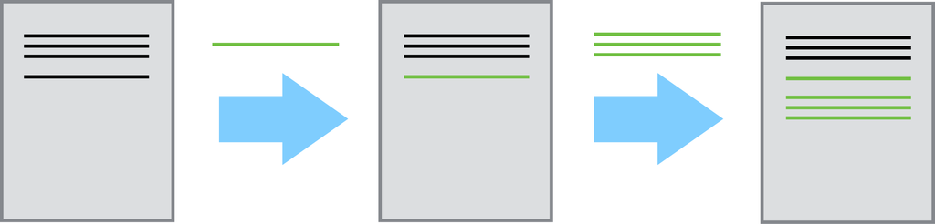

- "Playing back" different sets of changes onto the base document and getting different versions of the document.

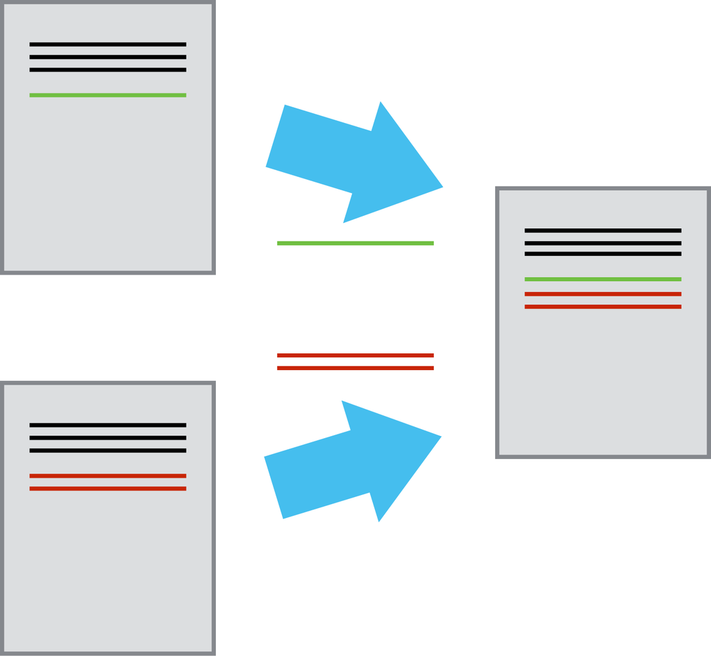

Source: [Software Carpentry](https://software-carpentry.org/).

## Git/GitHub

- Easy to set up
- Integrated with [RStudio](http://www.rstudio.com)
- GitHub's strong community: your colleagues are probably already there
- Provides tools to help enhance collaboration
- A common location to share your work

> Note: GitHub repositories are **public**. Can request private repositories for education or research

## Commits

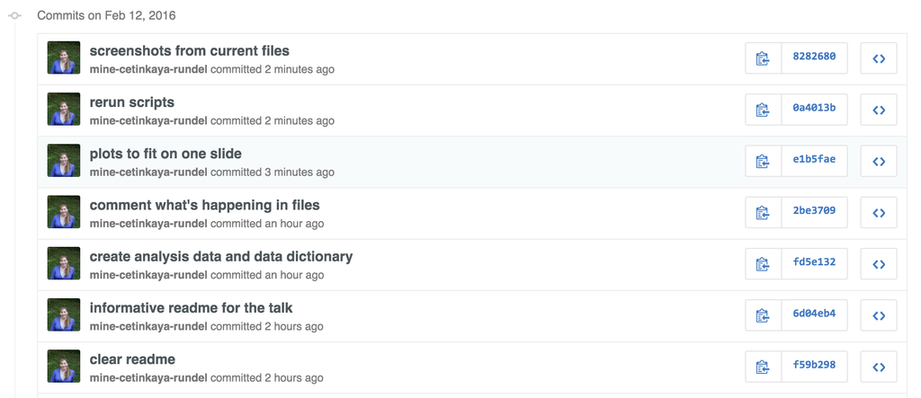

## Diff

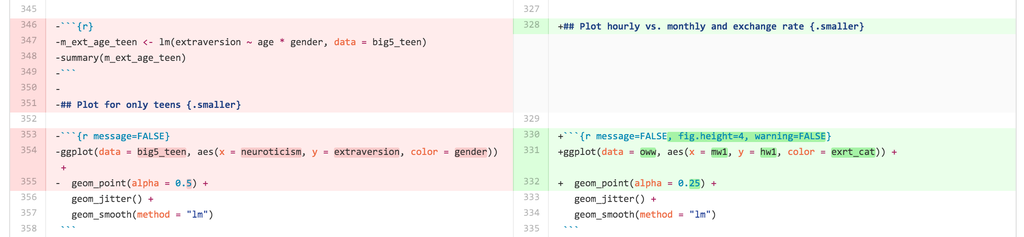

## Project TIER on GitHub

## Project TIER

You can find the folder structures outlined in the TIER Protocol in the Project TIER organization on GitHub:

https://github.com/ProjectTIER

- For R: Repository is called `ProjectTIER_R`
- For STATA: Repository **will be** called `ProjectTIER_STATA` (in progress)

## Fork

- Create a GitHub account if you don't yet have one: https://github.com/
- Form the `ProjectTIER_R` repository, which will create a copy in your account

## 2. Literate programming

## Donald Knuth "Literate Programming (1983)"

"Instead of imagining that our main task is to instruct a *computer* what to do, let us concentrate rather on explaining to *human beings* what we want a computer to do."

"The practitioner of literate programming […] strives for a program that is comprehensible because its concepts have been introduced in an order that is best for human understanding, using a mixture of formal and informal methods that reinforce each other."

- These ideas have been around for years!
- and tools for putting them to practice have also been around
- but they have never been as accessible as the current tools

## A better solution than just R

With RStudio you can combine your programming and your documentation

- Gives you a single environment to combine your documentation and your analysis
- Runs on top of R

[figure not shown]

## What is Markdown?

- Markdown is a lightweight markup language for creating HTML (or XHTML) documents.
- Markup languages are designed to produce documents from human readable text (and annotations).
- Some of you may be familiar with LaTeX. This is another (less human friendly) markup language for creating pdf documents.
- Why I love Markdown:
  - Simple syntax means easy to learn and use.
  - Focus on **content**, rather than **coding** and debugging **errors**.
  - Allows for easy web authoring.
  - Once you have the basics down, you can get fancy and add HTML, JavaScript, and CSS.

## Sample Markdown document

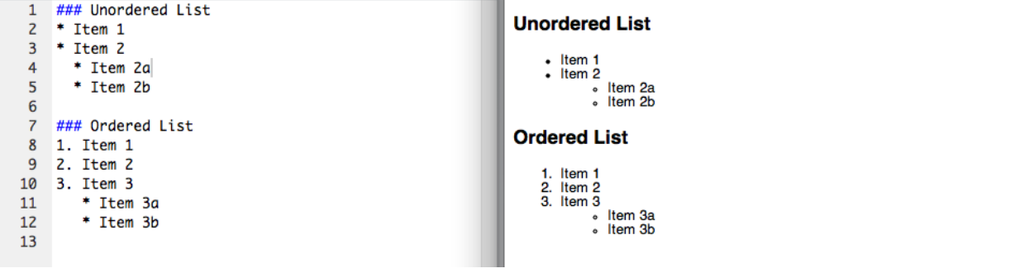

## What is R Markdown?

Well, it's R + Markdown:

- Ease of Markdown syntax
- Rendering of R code to produce output and plots

## Sample R Markdown document

[figure not shown]

## Another R Markdown document

This presentation!

## 3. Scriptability

## Point-and-click vs. scripting

- Learning curve: Point-and-click software (supposedly) have shallower learning curves than scripting languages
- Documentation: At a minimum, your code documents your analysis
  - And you can do better with comments and README files
- Automation: Need to rerun your analysis with new/updated data? Just change the input file.
- Collaboration: Sharing your analysis is as easy as sharing your scripts

## Why R?

- Programming language for data analysis
- Free!
- Open source
- Widely used and supported across all disciplines
- Can be used on Windows, Mac OS X, or Linux
- Thousands of statistical data analysis packages

[figure not shown]

## Why not language X?

- There are a number of other great programming tools out there that can also be used to improve the reproducibility of your analysis
- The key is to use some type of language that will allow you to automate and document your analysis
- Once you master one language you'll probably find it easier to learn another

## Once in R

You could just type into the command prompt, but that doesn't help much with

- documentation

or

- automation

[figure not shown]

## Example: Occupational Wages around the World

The [OWW database](http://www.nber.org/oww/) contains occupational wage data for 161 occupations in 171 countries from 1983 to 2008. The occupational wage data are derived from the [ILO October Inquiry database](http://laborsta.ilo.org) by calibrating the data into a normalized wage rate for each occupation. The normalized wages refer to average hourly or monthly wage rates for adult workers.

Load data with an **R chunk**:

```r
load("processing-and-analysis/analysis-data/oww.RData")
```

Source: http://www.nber.org/oww/

## Under the hood

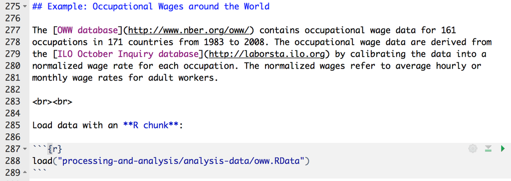

## View data

```r
oww
```

```
## Source: local data frame [125,018 x 37]
##
##     year country_ILO country_WDI industry occupation   hw1     hw2wu
##    (int)      (fctr)      (fctr)   (fctr)     (fctr) (dbl)     (dbl)
## 1   1989          AG         ATG       AA          1    NA  9.418722
## 2   1990          AG         ATG       AA          1    NA  6.350042
## 3   1992          AG         ATG       AA          1    NA  7.134442
## 4   1993          AG         ATG       AA          1    NA  9.047402
## 5   1994          AG         ATG       AA          1    NA 11.975790
## 6   1995          AG         ATG       AA          1    NA 15.325243
## 7   1996          AG         ATG       AA          1    NA  7.690887
## 8   1989          AG         ATG       AA          2    NA  6.369058
## 9   1990          AG         ATG       AA          2    NA  5.319535
## 10  1992          AG         ATG       AA          2    NA  5.295086
## ..   ...         ...         ...      ...        ...   ...       ...
## Variables not shown: hw3wu (dbl), hw4wu (dbl), hw2wl (dbl), hw3wl (dbl),
##   hw4wl (dbl), hw1us (dbl), hw2wuus (dbl), hw3wuus (dbl), hw4wuus (dbl),
##   hw2wlus (dbl), hw3wlus (dbl), hw4wlus (dbl), mw1 (dbl), mw2wu (dbl),
##   mw3wu (dbl), mw4wu (dbl), mw2wl (dbl), mw3wl (dbl), mw4wl (dbl), mw1us
##   (dbl), mw2wuus (dbl), mw3wuus (dbl), mw4wuus (dbl), mw2wlus (dbl),
##   mw3wlus (dbl), mw4wlus (dbl), curr (fctr), exrt (dbl), conv (dbl),
##   curr_conv (fctr).
```

## Clean data

You can include script files in your R Markdown document

```r
source("processing-and-analysis/command-files/02-data-cleanup.R")
```

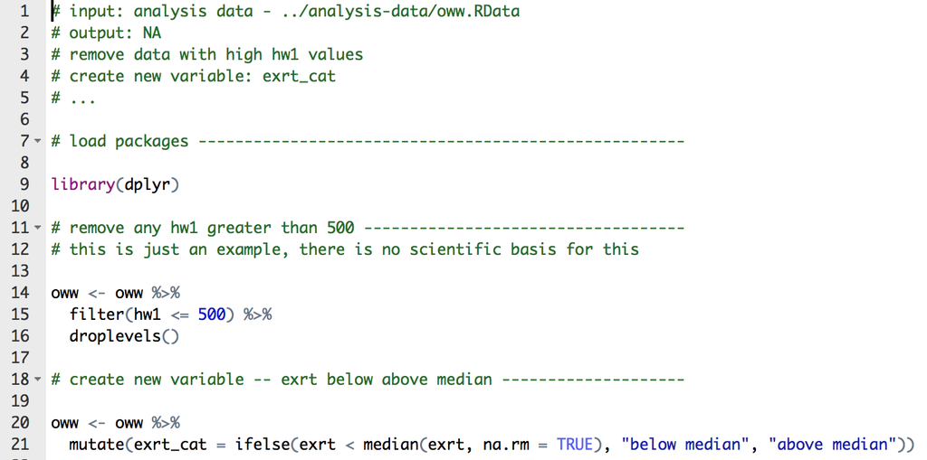

## View distribution of `hw1`

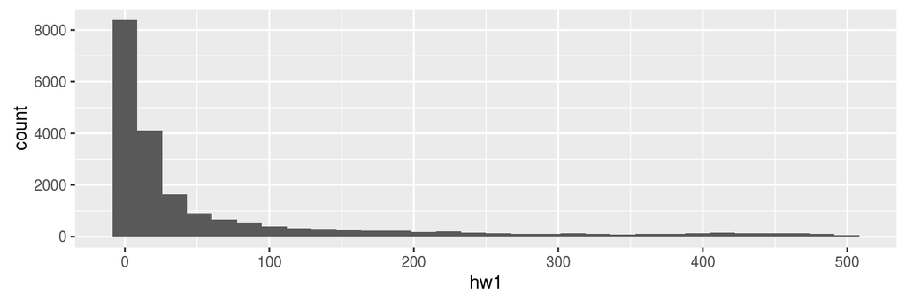

```r
ggplot(oww, aes(x = hw1)) +
  geom_histogram()
```

```r
summary(oww$hw1)
```

```
##     Min.  1st Qu.   Median     Mean  3rd Qu.     Max.
##   0.1279   5.0610  11.9700  64.1300  63.2600 499.9000
```

## Regress hourly vs. monthly and exchange rate

```r
m_hw1_mw1 <- lm(hw1 ~ mw1 * exrt_cat, data = oww)
summary(m_hw1_mw1)
```

```
##
## Call:
## lm(formula = hw1 ~ mw1 * exrt_cat, data = oww)
##
## Residuals:
##     Min      1Q  Median      3Q     Max
## -298.31   -1.19   -0.42    0.70  366.74
##
## Coefficients:
##                            Estimate Std. Error  t value Pr(>|t|)
## (Intercept)               8.781e-01  1.751e-01    5.014 5.39e-07 ***
## mw1                       5.678e-03  5.424e-06 1046.711  < 2e-16 ***
## exrt_catbelow median     -5.409e-01  2.238e-01   -2.416   0.0157 *
## mw1:exrt_catbelow median  3.374e-04  2.706e-05   12.468  < 2e-16 ***
## ---
## Signif. codes:  0 '***' 0.001 '**' 0.01 '*' 0.05 '.' 0.1 ' ' 1
##
## Residual standard error: 12.53 on 18729 degrees of freedom
##   (1501 observations deleted due to missingness)
## Multiple R-squared:  0.9877, Adjusted R-squared:  0.9877
## F-statistic: 5.033e+05 on 3 and 18729 DF,  p-value: < 2.2e-16
```

## Plot hourly vs. monthly and exchange rate

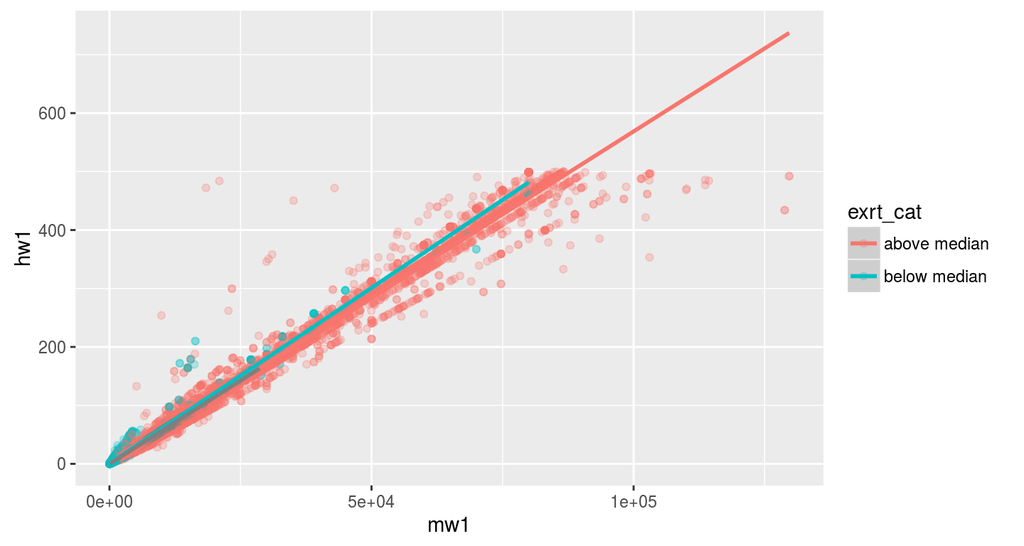

```r
ggplot(data = oww, aes(x = mw1, y = hw1, color = exrt_cat)) +
  geom_point(alpha = 0.25) +
  geom_smooth(method = "lm")
```

## Math typesetting

LaTeX:

\(\hat{y} = \beta_0 + \beta_1 \times x\)

## Set up git in RStudio

We're going to avoid local installation for now…

Go to https://vm-manage.oit.duke.edu/containers

- Log in with your Duke NetID
- Click on RStudio which will launch an R session for you

In RStudio:

- Go to Tools -> Shell
- Type the two lines of code, replacing my information with your own

```
$ git config --global user.name "Mine Cetinkaya-Rundel"
$ git config --global user.email "mine@stat.duke.edu"
```

## Clone

In RStudio:

- Go to File -> New Project -> Version Control -> Git
- Go back to your forked GitHub repo and copy the HTTPS URL
- Insert this into Repository URL
- Click on Create Project

## Edit, stage, commit, push

- Edit one of the Markdown files
- Go to the Git page in RStudio
  - Stage changes by checking the box
  - Commit (with an informative message)
  - Push
- View your changes on GitHub

## git/GitHub, why?

**Most powerful argument:** Automatic tracking of changes

**Other arguments:**

- No download/upload
- Ease of collaboration with ability to resolve merge conflicts
- Searchability
- …

## Parting remarks

## Two-pronged approach

Everyone struggles with reproducibility and it is a hindrance to moving science forward.

#1 Adopt a reproducible research workflow

#2 Train new researchers who don’t have any other workflow

[figure not shown]

## Resources

- This talk:
  - Repo: https://github.com/mine-cetinkaya-rundel/2016-02-12-project-tier-duke
  - Slides in your browser: http://bit.ly/tier_duke
- Project TIER on GitHub: https://github.com/ProjectTIER
- Learn more:
  - R Markdown: http://rmarkdown.rstudio.com/
  - RStudio and git: https://support.rstudio.com/hc/en-us/articles/200532077-Version-Control-with-Git-and-SVN
  - Try Git: https://try.github.io
  - Reproducible Science Curriculum (2 day workshop): https://github.com/Reproducible-Science-Curriculum/